# Time Series Analysis.

This notebook uses the kaggle data ([link](https://www.kaggle.com/datasets/nikhil1e9/netflix-stock-price)) on stock prices for the MAANG companies - *Meta, Apple, Amazon, Netflix and Google* since their IPO.

For our study we focus on the closing values (USD) for business days focusing between fixed dates for easy standardisation.

This is a naive inplementation to practice the understanding of time series analysis.

We cover the following -

```
1 Initial Exploration
    * Standardising the data
    * Resampling using business days, months
    * Visualising

2 Statistical Analysis
    * Series decomposition - decompose the timesereis for each company data to check for Seasonality, Trend, and, Variance
    * ACF and PACF plots
    * Stationarity checks

1. Fitting time series models & forecasting
    * using exponential smoothing
    * using statsmodels
    * using Prophet

2. Fitting using NN
    * using SimpleRNN
    * using LSTM
```

```python
import numpy as np
import pandas as pd
import seaborn as sns

import matplotlib.pyplot as plt
import warnings
warnings.filterwarnings('ignore')
```

```python
companyNames = ['AMAZON', 'APPLE', 'GOOGLE', 'META', 'NETFLIX']
```

### Data constraints

We will set a `minimum` and a `maximum` date for the stock data. This will limit the analysis of the #MAANG dataset to a uniform timeline. The variable used for the analyis is the closing value of the stock for that day in US dollars `$`

> For our purpose we chose format `YYYY-MM-DD`

```
min = '2019-01-01'
max = '2024-01-10'
```

```python
## setting the minimum and maximum date
minDate = '2019-01-01'
maxDate = '2024-01-10'
```

```python
def standardiseData(dataFrame,minDate=minDate,maxDate=maxDate):

    new_index = pd.date_range(minDate,maxDate,freq='B') # dates between which we obderve the time Series

    dataFrame['Date'] = pd.to_datetime(dataFrame['Date'],yearfirst=True)
    dataFrame.set_index('Date',inplace=True)
    dataFrame = dataFrame[minDate:maxDate]

    newDF = dataFrame.reindex(new_index,method='bfill')

    newDF = newDF[['Close']]
    return newDF
```

```python
def checkData(df,minDate=minDate,maxDate=maxDate):

    days = len(pd.date_range(minDate,maxDate,freq='B'))

    assert len(df) == days
    assert df['Close'].dtypes == 'float64'
    assert df.index.dtype == '<M8[ns]'

    return None
```

```python
def create_AnalysisData(companyNames,logData=False):

    ## initialising the final Df to df_0 for merging with the others.

    listDF = []
    final_cols = []
    for i in range(len(companyNames)):
        final_cols.append(companyNames[i])
        df_i = pd.read_csv(f'data/{companyNames[i]}_daily.csv', header=0)
        df_i = standardiseData(df_i)
        checkData(df_i)

        listDF.append(df_i)

    finalDF = pd.concat(listDF,ignore_index=False,axis=1)
    finalDF.columns = final_cols

    if logData:

        finalDF = finalDF.apply(np.log10,axis=0)

    return finalDF
```

```python
timeSeriesData = create_AnalysisData(companyNames)
```

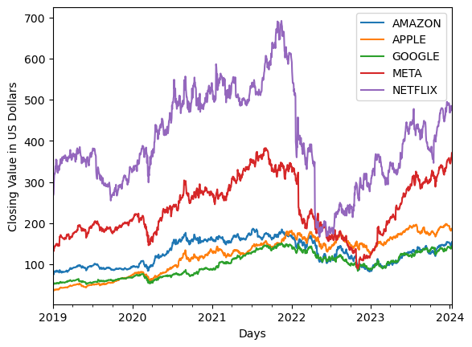

```python
timeSeriesData.plot(xlabel='Days',ylabel='Closing Value in US Dollars')
```

```python
from statsmodels.graphics.tsaplots import plot_acf, plot_pacf, month_plot
from statsmodels.tsa.seasonal import seasonal_decompose
```

```
Analysing for GOOGLE
```

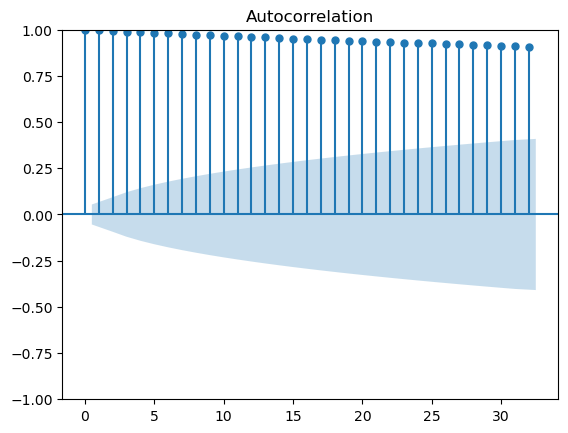

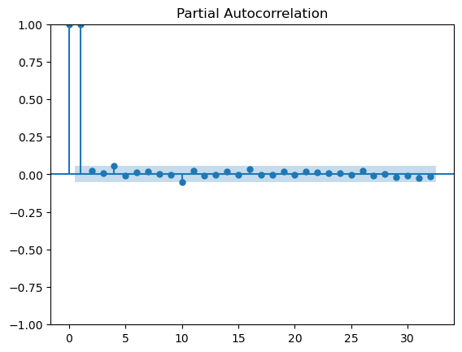

```python
company = companyNames[2]

print(f'Analysing for {company}')

acf_plots = plot_acf(timeSeriesData[company])
pacf_plots = plot_pacf(timeSeriesData[company])
```

```python
## performing seasonal decomposition on the time Series

ts_decomposition = seasonal_decompose(x=timeSeriesData[company],model='multiplicative',period=6)
```

```python
def plot_decompose(TS,decomposition):
    '''
        this function plots the original time series along with the
        trend,seasonaloty and residuls extracted from the decomposition model: 'multiplicative'

    '''
    est_trend = decomposition.trend
    est_seasonality = decomposition.seasonal
    est_residual = decomposition.resid

    fig,axes = plt.subplots(4,1,sharex=True,sharey=False,figsize=(16,5))

    axes[0].plot(TS,label='Original')
    axes[0].legend(loc='upper left')

    axes[1].plot(est_trend,label='Trend')
    axes[1].legend(loc='upper left')

    axes[2].plot(est_seasonality,label='Seasonality')
    axes[2].legend(loc='upper left')

    axes[3].plot(est_residual,label='Residuals')
    axes[3].legend(loc='upper left')

    return est_trend,est_seasonality,est_residual
```

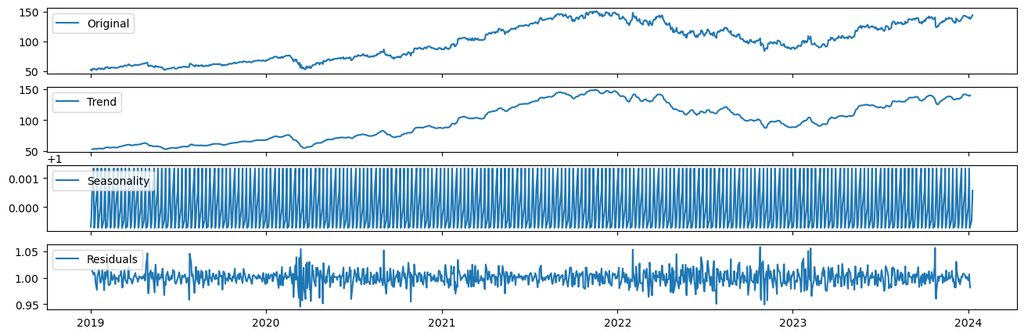

```python
T,S,R = plot_decompose(timeSeriesData[company],ts_decomposition)
```

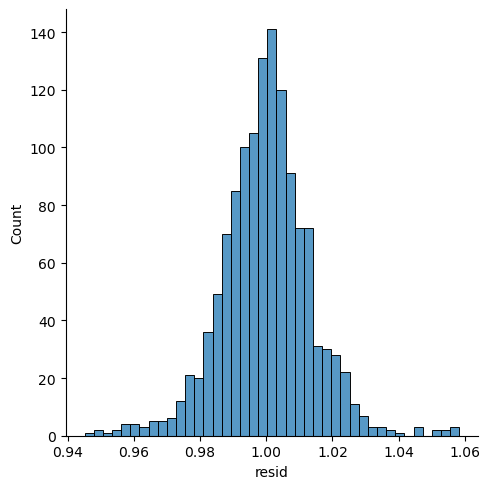

```python
sns.displot(R)
```

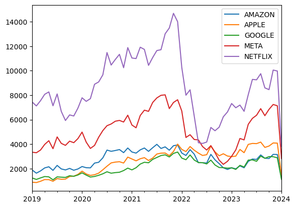

```python
## Creating monthly values by summing

timeSeriesData_monthly = timeSeriesData.resample('M').sum()

timeSeriesData_monthly.plot()
```

```
Monthly Seasonal plot for GOOGLE stock
```

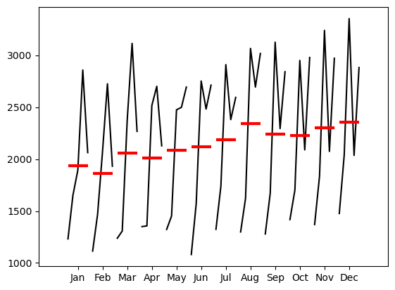

```python
## Create a month plot for an example time Series

print(f'Monthly Seasonal plot for {company} stock')
mplot = month_plot(timeSeriesData_monthly[company][:-1]) ## we add [:-1] at the end because the data for the jan 2024 is not complete
```

```python
## Creating rolling average with a user defined window size.

window_size = 30
timeSeriesData_rolling = timeSeriesData.rolling(window_size).mean().dropna()
```

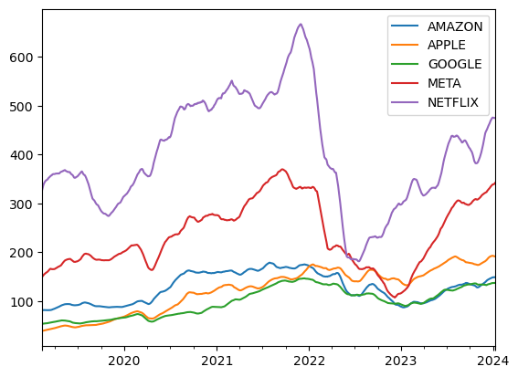

```python
timeSeriesData_rolling.plot()
```

## Smoothing using Exponential methods

> Single Exponential - Captures neither trend or seasonality

```
    from statsmodels.tsa.api import SimpleExpSmoothing
```

> Double Exponential - Captures trend

```
    from statsmodels.tsa.api import Holt
```

> Triple Exponential - Captures both trend and seasonality

```
    from statsmodels.tsa.api import ExponentialSmoothing
```

```python
from statsmodels.tsa.api import SimpleExpSmoothing, Holt, ExponentialSmoothing

split_at = 100
train,test = timeSeriesData_rolling[company][:-split_at], timeSeriesData_rolling[company][-split_at:]
train_time,test_time = timeSeriesData_rolling.index.values[:-split_at], timeSeriesData_rolling.index.values[-split_at:]

## Single Exponential Smoothing
singleExp = SimpleExpSmoothing(train).fit(optimized=True)
singleExp_pred = singleExp.forecast(len(test))

# Double Exponential Smoothing
doubleExp = Holt(train).fit(optimized=True)
doubleExp_pred = doubleExp.forecast(len(test))

# Triple Exponential Smoothing
tripleExp = ExponentialSmoothing(train,
                                 trend='multiplicative',
                                 seasonal='multiplicative',
                                 seasonal_periods=13).fit(optimized=True)
tripleExp_pred = tripleExp.forecast(len(test))
```

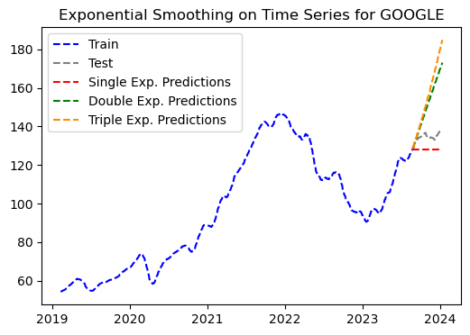

```python
fig = plt.figure(figsize=(6,4))
ax = fig.add_subplot(111)

ax.set_title(f'Exponential Smoothing on Time Series for {company}')

ax.plot(train_time,train,'--b',label='Train')
ax.plot(test_time,test,'--', color='gray',label='Test')
ax.plot(test_time,singleExp_pred,'--', color='red',label='Single Exp. Predictions')
ax.plot(test_time,doubleExp_pred,'--', color='green',label='Double Exp. Predictions')
ax.plot(test_time,tripleExp_pred,'--', color='darkorange',label='Triple Exp. Predictions')
ax.legend()
```

## ARMA modeling

```python
### checking for stationarity

from statsmodels.tsa.stattools import kpss

statistic, p_value, n_lags, critical_values = kpss(train)

print(f"KPSS Statistic: {statistic}")
print(f"p-value: {p_value}")
print(f"num lags: {n_lags}")
print("Critial Values:")

print(f'Result: The series is {"not " if p_value < 0.05 else ""}stationary')


print('Running the stationarity check on the difference series')

train_diff = train.diff().dropna()

statistic, p_value, n_lags, critical_values = kpss(train_diff)

print(f"KPSS Statistic: {statistic}")
print(f"p-value: {p_value}")
print(f"num lags: {n_lags}")
print("Critial Values:")

print(f'Result: The series is {"not " if p_value < 0.05 else ""}stationary')
```

```
KPSS Statistic: 3.7897773662394583
p-value: 0.01
num lags: 20
Critial Values:
Result: The series is not stationary
Running the stationarity check on the difference series
KPSS Statistic: 0.2590446025501215
p-value: 0.1
num lags: 20
Critial Values:
Result: The series is stationary
```

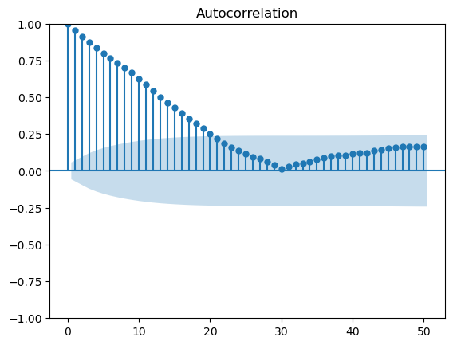

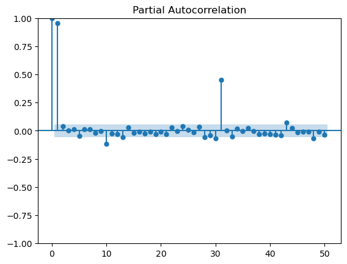

```python
acf_diff = plot_acf(train_diff,lags=50)
pacf_diff = plot_pacf(train_diff,lags=50)
```

```python
from statsmodels.tsa.arima.model import ARIMA as arima_model
from pmdarima.arima import auto_arima

auto_model = auto_arima(train)
auto_model.summary()
```

SARIMAX Results

| Dep. Variable: | y | No. Observations: | 1183 |
| --- | --- | --- | --- |
| Model: | SARIMAX(0, 2, 1) | Log Likelihood | 1196.289 |
| Date: | Wed, 24 Jan 2024 | AIC | -2388.579 |
| Time: | 15:26:42 | BIC | -2378.431 |
| Sample: | 02-11-2019 | HQIC | -2384.753 |
|  | - 08-23-2023 |  |  |
| Covariance Type: | opg |  |  |

|  | coef | std err | z | P>\|z\| | [0.025 | 0.975] |
| --- | --- | --- | --- | --- | --- | --- |
| ma.L1 | -0.0671 | 0.024 | -2.802 | 0.005 | -0.114 | -0.020 |
| sigma2 | 0.0077 | 0.000 | 30.441 | 0.000 | 0.007 | 0.008 |

| Ljung-Box (L1) (Q): | 0.00 | Jarque-Bera (JB): | 72.61 |
| --- | --- | --- | --- |
| Prob(Q): | 0.96 | Prob(JB): | 0.00 |
| Heteroskedasticity (H): | 3.51 | Skew: | 0.03 |
| Prob(H) (two-sided): | 0.00 | Kurtosis: | 4.21 |

Warnings:  
[1] Covariance matrix calculated using the outer product of gradients (complex-step).

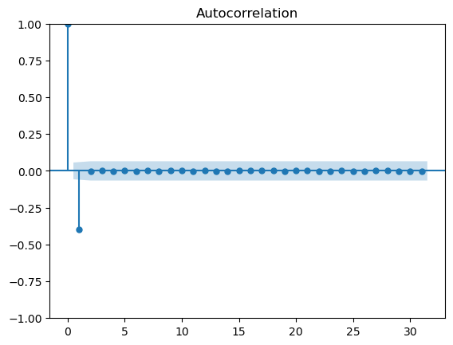

```python
auto_model_resid = auto_model.resid()

plot_resid = plot_acf(auto_model_resid)
```

```python
p,d,q = 1,1,0

arima_model21 = arima_model(train,order=(p,d,q))
arima_resid = arima_model21.fit()
```

```python
arima_resid.summary()
```

SARIMAX Results

| Dep. Variable: | GOOGLE | No. Observations: | 1183 |
| --- | --- | --- | --- |
| Model: | ARIMA(1, 1, 0) | Log Likelihood | 1206.544 |
| Date: | Wed, 24 Jan 2024 | AIC | -2409.089 |
| Time: | 15:26:44 | BIC | -2398.939 |
| Sample: | 02-11-2019 | HQIC | -2405.262 |
|  | - 08-23-2023 |  |  |
| Covariance Type: | opg |  |  |

|  | coef | std err | z | P>\|z\| | [0.025 | 0.975] |
| --- | --- | --- | --- | --- | --- | --- |
| ar.L1 | 0.9570 | 0.008 | 121.402 | 0.000 | 0.942 | 0.972 |
| sigma2 | 0.0076 | 0.000 | 31.321 | 0.000 | 0.007 | 0.008 |

| Ljung-Box (L1) (Q): | 2.09 | Jarque-Bera (JB): | 90.73 |
| --- | --- | --- | --- |
| Prob(Q): | 0.15 | Prob(JB): | 0.00 |
| Heteroskedasticity (H): | 3.40 | Skew: | -0.11 |
| Prob(H) (two-sided): | 0.00 | Kurtosis: | 4.34 |

Warnings:  
[1] Covariance matrix calculated using the outer product of gradients (complex-step).

```python
from statsmodels.graphics.tsaplots import plot_predict
```

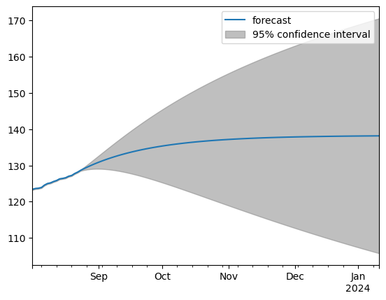

```python
plot_predict(arima_resid,start="2023-08-02",end="2024-01-10",dynamic=False)
plt.show()
```

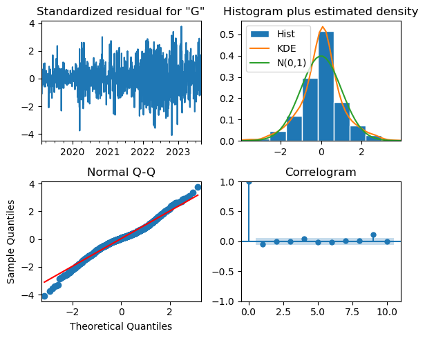

```python
diagnostics = arima_resid.plot_diagnostics(figsize=(6,5))
plt.tight_layout()
```

```python
arima_pred = arima_resid.forecast(split_at,alpha=0.05)
fitted = arima_resid.get_forecast(split_at)

conf_int_95 = fitted.conf_int(alpha=0.05)
conf_int_90 = fitted.conf_int(alpha=0.10)
```

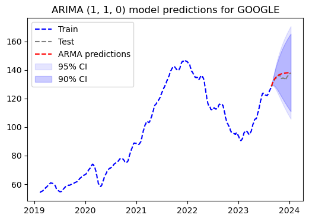

```python
fig = plt.figure(figsize=(6,4))
ax = fig.add_subplot(111)

ax.set_title(f'ARIMA {p,d,q} model predictions for {company}')

ax.plot(train_time,train,'--b',label='Train')
# ax.plot(train_time[1:],arima_resid.fittedvalues[1:],'-k',label='Model Fitted Values')
ax.plot(test_time,test,'--', color='gray',label='Test')
ax.plot(test_time,arima_pred,'--', color='red',label='ARMA predictions')
ax.fill_between(
    conf_int_95.index,
    conf_int_95[f"lower {company}"],
    conf_int_95[f"upper {company}"],
    color="b",
    alpha=0.1,
    label="95% CI"
)

ax.fill_between(
    conf_int_90.index,
    conf_int_90[f"lower {company}"],
    conf_int_90[f"upper {company}"],
    color="b",
    alpha=0.2,
    label="90% CI"
)
ax.legend(loc="upper left")
```

# Using Meta Prophet

```python
from prophet import Prophet
```

```python
P_model = Prophet()

##3 Prophet needs columns ds and y in the data frame.. hence we will have to modify the train dataset

def modify_train(df,company):

    trainDF = pd.DataFrame()
    trainDF['ds'] = df.index
    trainDF['y'] = df[company].values

    return trainDF

train_prophet = modify_train(timeSeriesData_rolling[:-split_at],company)

P_model.fit(train_prophet)
```

```
15:27:01 - cmdstanpy - INFO - Chain [1] start processing
15:27:02 - cmdstanpy - INFO - Chain [1] done processing
```

```
<prophet.forecaster.Prophet at 0x2a790ee50>
```

```python
future = P_model.make_future_dataframe(periods = 100,freq = 'B') # could also leave default freq of days and do 31 for period
future.tail()
```

|  | ds |
| --- | --- |
| 1278 | 2024-01-04 |
| 1279 | 2024-01-05 |
| 1280 | 2024-01-08 |
| 1281 | 2024-01-09 |
| 1282 | 2024-01-10 |

```python
# populate forecast
P_forecast = P_model.predict(future)
print(P_forecast.columns)
P_forecast[['ds', 'yhat', 'yhat_lower', 'yhat_upper']].tail()
```

```
Index(['ds', 'trend', 'yhat_lower', 'yhat_upper', 'trend_lower', 'trend_upper',
       'additive_terms', 'additive_terms_lower', 'additive_terms_upper',
       'weekly', 'weekly_lower', 'weekly_upper', 'yearly', 'yearly_lower',
       'yearly_upper', 'multiplicative_terms', 'multiplicative_terms_lower',
       'multiplicative_terms_upper', 'yhat'],
      dtype='object')
```

|  | ds | yhat | yhat_lower | yhat_upper |
| --- | --- | --- | --- | --- |
| 1278 | 2024-01-04 | 111.696742 | 83.097621 | 138.468212 |
| 1279 | 2024-01-05 | 111.556865 | 82.581322 | 139.041322 |
| 1280 | 2024-01-08 | 111.045020 | 81.647961 | 138.504043 |
| 1281 | 2024-01-09 | 110.928978 | 80.753761 | 139.435411 |
| 1282 | 2024-01-10 | 110.819943 | 80.898092 | 139.181263 |

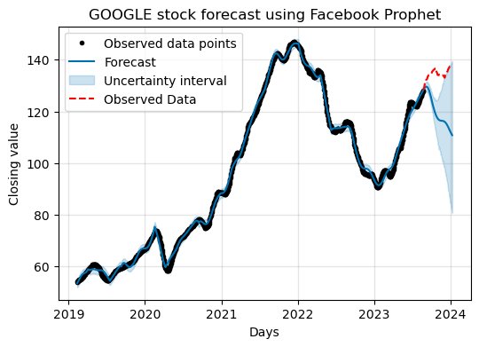

```python
fig = plt.figure(figsize=(6,4))
ax = plt.subplot(111)
_ = P_model.plot(P_forecast,ax=ax,xlabel='Days',ylabel='Closing value',include_legend=True)
ax.plot(test,'r--', label='Observed Data')
ax.set_title(f'{company} stock forecast using Facebook Prophet')
ax.legend()
```

# Using Deep Learning

We will use the following methods to do the Deep Learning based forecasting of the time series

> 1. Simple RNNs
> 2. LSTM

But before we do any of that we need to prepare the data so that it can be used as an input for the Neural Networks framework.

> [!NOTE] The input format required for RNN is a 3D numpy array : `(n_samples,time_steps,n_features)`

> Since we only have 1 time series .. we will create multiple sample from it

> And form a set for train_X, test_X, train_Y, test_y

> [!WARNING]

> The test_X should be of the same length as train_X :

> Since a simpleRNN is a many-to-one architecture and should have a fixed input length

### Parameters for preparing the input

> We will have to create many samples from the train data to feed into the RNN. We do so by extracting a sequence of fixed sizes from the series with the output for that sequence being the next item after the sequence.

```
1. split_at : (int) Split the series into train and test parts
2. input_size : (int) defines the size of the sequence input to be fed into the RNN
3. step_size : steps to jump before the start of the next train sample from the entire train series.
```

```python
def convert_to_keras_format(series):
    '''
        this is to convert the series into keras acceptable format for RNNs
        that is a 3-D array
    '''
    series = np.array(series)

    return series.reshape(series.shape[0],series.shape[1],1)
```

```python
def train_test_split_(series, split_at=100, input_size=20, step_size=5):

    """
        Splits the data set in to training and test sets and converts the series into the
        requires keras format i.e a 3-d array:

        ==========================================
        arguments -

        series : data sets as a pandas series, or a list
        split_at : index from where to separate the train and test parts  -- beginning from the end
        input_size : fixed size of the input sequence to be fed into the RNN ..
                     this means that if input_size=5 then RNN will learn the effect of last 5 steps
                     in the series to predict the next step.
        step_size: this is the jump needed to begin a new train sample from a different starting point.
    """

    train,test = series[:-split_at], series[-split_at:]

    train_X,train_Y = [],[]

    for i in range(0,train.shape[0]-input_size,step_size):

        train_X.append(train[i:i+input_size])
        train_Y.append(train[i+input_size])

    train_X = convert_to_keras_format(train_X)
    train_Y = np.array(train_Y)

    test_x = test[:input_size]
    test_y = test[input_size:]

    return train_X,train_Y,test_x,test_y
```

```python
train_X,train_Y,test_x,test_y = train_test_split_(timeSeriesData_rolling[company])
```

```python
print('Training input shape: {}'.format(train_X.shape))
print('Training output shape: {}'.format(train_Y.shape))
print('Test input shape: {}'.format(test_x.shape))
print('Test output shape: {}'.format(test_y.shape))
```

```
Training input shape: (233, 20, 1)
Training output shape: (233,)
Test input shape: (20,)
Test output shape: (80,)
```

```python
import tensorflow as tf
import keras
from keras.models import Sequential
from keras.layers import Dense, SimpleRNN, LSTM, Activation, Dropout
import math
from sklearn.preprocessing import MinMaxScaler
from sklearn.metrics import mean_squared_error
```

```python
def fit_simple_RNN(train_X,train_Y,cell_units=10,epochs=10):

    """
    Fits the SimpleRNN from tensorflow

    ==============================

    arguments :

    train_X : training data with shape (n_samples,n_timesteps,n_features)
    train_Y : target variables for prediction
    cell_units : number of cells in the Sequential RNN
    epochs : number of epochs for which the model is to be trained

    """
    # initialising a model
    model = Sequential()

    ## construct a RNN layer with suer define number of cell unit
    ## and input with fixed step size and 1 feature i.e the history of the series
    model.add(SimpleRNN(cell_units,input_shape=(train_X.shape[1],1)))

    ## ouput layer for predictions
    model.add(Dense(1))

    ## defining run parameters with epochs, loss and optimizer
    model.compile(loss='mean_squared_error', optimizer='adam')
    model.fit(train_X,train_Y,epochs=epochs, batch_size=64, verbose= 0)

    return model
```

```python
model = fit_simple_RNN(train_X,train_Y,cell_units=25,epochs=500)
```

```python
history = model.history.history
```

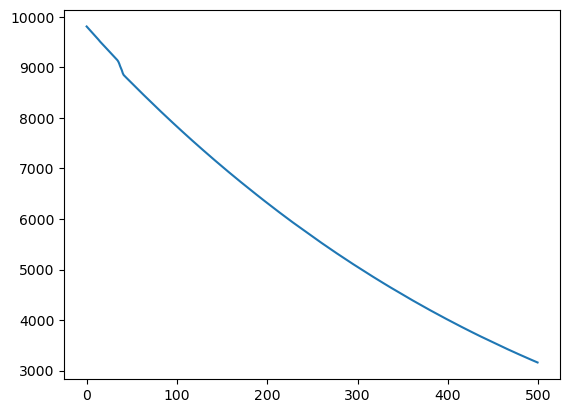

```python
plt.plot(history['loss'])
```

### Predictions -

> [!TIP] To make predictions using the trained model we will use the `text_X` and `test_y` Remember we need to make predictions throughout the length of `y` , so we will iteratively shift values of `test_X` by replacing the last value with the prediction.

> We do this untill we exhaust the length of `test_y`.

> [!NOTE] Follow lectures from `IBM` course on *Time-Series Analysis* or *Deeplearning Specialization* by `DeepLearning.ai`

> on `Coursera` for a detailed explanation.

```python
def make_predictions(test_x,model,n_steps=len(test_y)):

    test_x = np.array(test_x)
    test_x_init = test_x.copy().reshape(1,-1,1)

    predictions = []

    for _ in range(n_steps):

        pred = model.predict(test_x_init)
        predictions.append(pred)
        test_x_init[:,:-1,:] = test_x_init[:,1:,:]
        test_x_init[:,-1,:] = pred

    predictions = np.array(predictions).reshape(-1,1)

    return predictions
```

```python
y_pred = make_predictions(test_x,model)
```

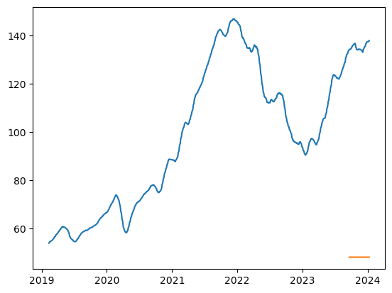

```python
plt.plot(timeSeriesData_rolling[company])

plt.plot(timeSeriesData_rolling[-80:].index,y_pred[:,0])
```

```python
def fit_LSTM(train_X, train_Y, cell_units, epochs):
    """
    Fit LSTM to data train_X, train_y

    arguments
    ---------
    train_X (array): input sequence samples for training
    train_y (list): next step in sequence targets
    cell_units (int): number of hidden units for LSTM cells
    epochs (int): number of training epochs
    """

    # initialize model
    model = Sequential()

    # construct a LSTM layer with specified number of hidden units
    # per cell and desired sequence input format
    model.add(LSTM(cell_units, input_shape=(train_X.shape[1],1))) #,return_sequences= True))
    #model.add(LSTM(cell_units_l2, input_shape=(train_X.shape[1],1)))

    # add an output layer to make final predictions
    model.add(Dense(1))

    # define the loss function / optimization strategy, and fit
    # the model with the desired number of passes over the data (epochs)
    model.compile(loss='mean_squared_error', optimizer='adam')
    model.fit(train_X, train_Y, epochs=epochs, batch_size=64, verbose=0)

    return model
```

```python
lstm_model = fit_LSTM(train_X,train_Y,cell_units=100,epochs=1000)
```

```python
y_lstm_pred = make_predictions(test_x,lstm_model)
```

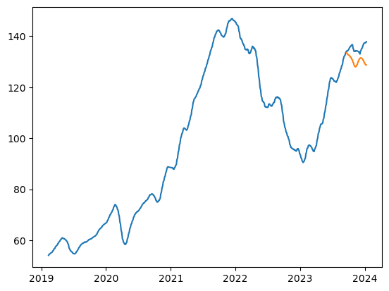

```python
plt.plot(timeSeriesData_rolling[company])

plt.plot(timeSeriesData_rolling[-80:].index,y_lstm_pred[:,0])
```

Based on th performance of the models -

> RNN - badly underfitting. Needs to be fine-tuned

> LSTM - better than RNN but still needs fine-tuning

### Summary -

Based on the analysis we observe that ARIMA (1,1,0) was able to capture the trend better than the exponential smoothing. We used ARIMA (1,1,0) since the series was not stationary until first differencing. Further exploration for a better choice of (p,d,q) variables is one of the future objectives.

A simple implementation of forecasting using `Prophet` was also used for comparison.

In the cased of deep learning methods, we used a simple RNN architecture (input size = 20, cell units = 25, epochs = 500) to make predictions. However the model badly underfits demanding fine tuning. The performance was improved when the model used LSTM (cell units = 100, epochs = 1000) but still needs improvement.

The future goal of this study is to work on inference methods and more statistical tests to make the results more robust. Use fine-tuning and cross-validation in neural network based forecasting for better predictions.

Some Helpful References -

https://www.kaggle.com/code/nikhil1e9/stock-price-forecasting-using-lstm

https://www.freecodecamp.org/news/the-ultimate-guide-to-recurrent-neural-networks-in-python/